# Simulation study: CLT

Zihan Fang

11/24/2020

# 1 Instruction

In this blog, I will explain my simulation study and results and comment on any patterns I observe. I am going to compare the sampling distribution of the mean generated by simulation to the sampling distribution implied by the central limit theorem in this simulation study. I will compare the distributions graphically in QQ-plots.

This will be a 4 × 4 factorial experiment. The first factor will be the sample size, with N = 5, 10, 20, and 40. The second factor will be the degree of skewness in the underlying distribution. The underlying distribution will be the Skew-Normal distribution. The Skew-Normal distribution has three parameters: location, scale, and slant. When the slant parameter is 0, the distribution reverts to the normal distribution. As the slant parameter increases, the distribution becomes increasingly skewed. In this simulation, slant will be set to 0, 2, 10, 100. Set location and scale to 0 and 1, respectively, for all simulation settings.

The output of each combination of factors will be a QQ-plot. Generate a sampling distribution of 5000 draws from both the CLT approximation and the simulation approximation. When analyzing data, the parameters for the mean and variance (in the case of the CLT shortcut) or the parameters for the distribution (in the case of MLE, MM, etc) are replaced with sample estimates. (This is often called the plug-in approach.) For the purposes of this simulation, treat the mean and variance as known values and use the actual population parameters and the population mean and variance instead of sample estimates.

# 2 Background

The central limit theorem is an important computational short-cut for generating and making inference from the sampling distribution of the mean. I’ll recall that the central limit theorem short-cut relies on a number of conditions, specifically:

1.Independent observations 2.Identically distributed observations 3.Mean and variance exist 4.Sample size large enough for convergence

# 3 Method

In this simulation, I will set the mean and variance as known values and use the true population parameters and the population mean and variance instead of estimated values.

```r
require(magrittr)
require(sn)
```

```r
# Parameters that do not change
R <- 5000; location <- 0; scale <- 1
# Generate a function to generate a qqplot
generate_qqplot <- function(N,slant){
delta <- slant / (sqrt(1 + slant ^ 2))
pop_mean <- location + scale * delta * sqrt(2 / pi)
pop_sd <- sqrt(scale ^ 2 * (1 - (2 * delta ^ 2) / pi))
#CLT approximation
sample_dist_clt <- (pop_sd/sqrt(N))*rnorm(R)+pop_mean
#Simulation approximation
random.skew <- array(rsn(R*N,xi=location,omega=scale,alpha=slant),dim=c(R,N))
sample_dist_sim <-apply(random.skew,1,mean)

#QQ plot
qqplot(sample_dist_sim,sample_dist_clt,axes = FALSE, frame.plot=TRUE, ann = FALSE)
abline(0,1)
}
```

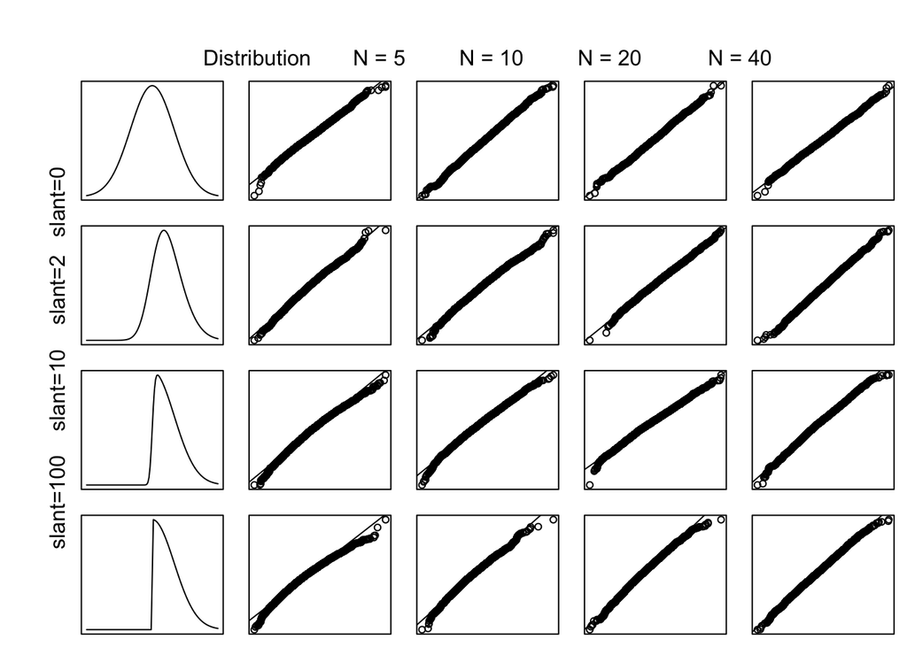

```r
#Parameters that change
slant <- c(0,2,10,100)
N <- c(5,10,20,40)
x <- seq(-3,3,by=0.05)
#Set graphical parameters
par(mfrow=c(4,5),mai=c(0.1,0.1,0.1,0.1), oma = c(0, 4, 4, 0))
#call the function for different slant and N
# Distribution
for (i in slant){
  plot(dsn(x, xi = location,omega = scale, alpha = i), type = "l",axes = FALSE, frame.plot=TRUE)
# QQ plot
for (n in N){
    generate_qqplot(n,i)
  }
}

mtext('slant=100    slant=10    slant=2   slant=0', side = 2, outer = TRUE)
mtext('Distribution       N = 5         N = 10         N = 20           N = 40', side = 3, outer = TRUE)
```

These graphs compare the sampling distribution of the mean generated by simulation to the sampling distribution implied by the central limit theorem. From these figures, we can see that the deviation in tails will increase as the slant increases. Also, as the sample size increases, the sampling distribution will fit y=x better.